# Appendix D5 - Tract Boundary Exploration

Nathan Garcia-Diaz

2023-05-08

# 1 Packing Preparation and Importing Datasets

The following chunk preforms the following tasks:

```
* makes a list of packages names needed throughout the document
* Makes Oregon States Counties Map
* Makes Marion County Census Tracts Map
    * Map 1: Census Tracts in 2015
    * Map 2: Census Tracts in 2020
```

```r
# importing packages
package_lst = c("tidyverse", "maps", "sf",
                "readxl", # importing excel files
                "imputeTS", # removes na with "na_remove()"
                "janitor", # creates clean column names
                # utilized to obtain acs data frames, spatial files, and map making
                "tigris", "tidycensus", "tmap", "ggpubr", "here")
#lapply(package_lst, install.packages, character.only = TRUE)
lapply(package_lst, library, character.only = TRUE)
```

# 2 Creating Map of Oregon Counties

The following code creates the maps for Oregon Counties.

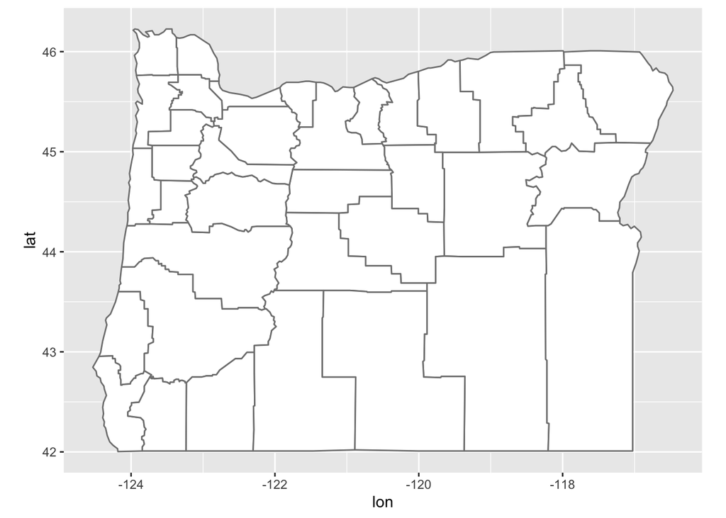

```r
## define the shape of the Oregon counties -- from maps package
or_counties <- map_data("county", "oregon") %>% select(lon = long, lat, group, id = subregion)
head(or_counties)

## plot Oregon counties
ggplot(or_counties, aes(lon, lat, group = group)) +
  geom_polygon(fill = "white", colour = "grey50") +
  coord_quickmap()
```

# 3 Creating Maps of Marion County Census-Tracts

The goal for the following code is to create ggplot two objects containing census tracts for Marion County in 2015 and 2020. To achieve this goal the following objective are met:

```
* define the census tract year
* pull the shape files for Marion County, from define cenus tract year
* create ggplot object using the shape files from the previous step
* repeat for second year
```

```r
# set year for boundaries
this.year = 2015

# define the shape of Oregon tracts -- from sf
or_tracts_2015 <- tracts(state = 'OR', county = 'Marion', cb = T, year = this.year)
head(or_tracts_2015)

# creating the 2015 shape maps
map_2015 = ggplot(or_tracts_2015) + geom_sf() + coord_sf()

# set year for boundaries
this.year = 2020

# define the shape of Oregon tracts -- from sf
or_tracts_2020 <- tracts(state = 'OR', county = 'Marion', cb = T, year = this.year)

head(or_tracts_2020)

# creating the 2015 shape maps
map_2020 = ggplot(or_tracts_2020) + geom_sf() + coord_sf()
```

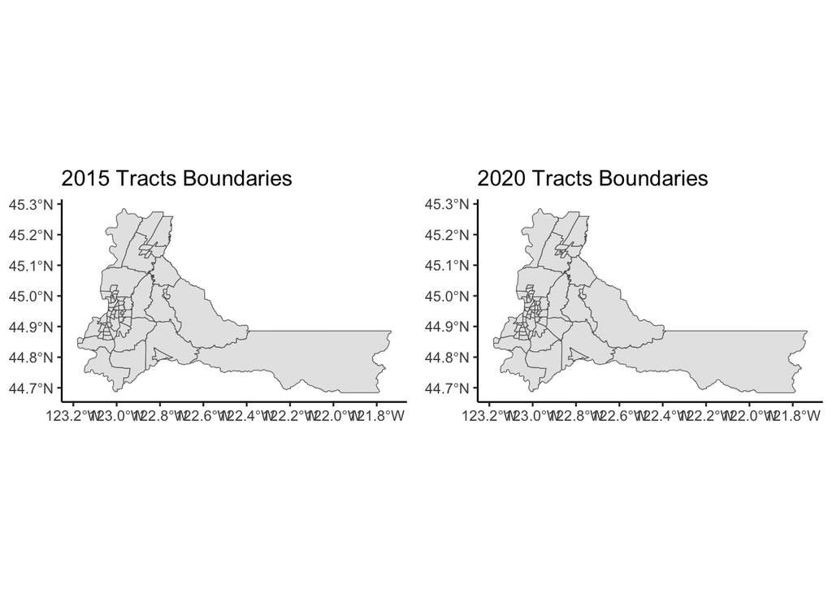

```r
map_2015 = map_2015 + ggtitle("2015 Tracts Boundaries") + theme_classic()

map_2020 = map_2020 + ggtitle("2020 Tracts Boundaries") + theme_classic()

temp = ggpubr::ggarrange(map_2015, map_2020 # defines the order of the plot
                     #,labels = c("A", "B") # defines the labels
                     ,font.label = list(size=14, color = "black", face = 'plain') # defines label aesthetics
                     ,ncol = 2, nrow = 1) # defines the organization of graphs
temp
```

```r
ggsave(filename=here("Outputs", "fig3.png"), plot = temp)
```

The following list demonstrates the relationship between census tracts in 2020 and 2015. The first line is the example relationship between the two years.

```
* **047_2020_tract_01** + **047_2020_tract_01** = **047_2015_tract**
1. 010308 + 010309 = 010306
2. 002503 + 002504 = 002501
3. 001605 + 001606 = 001602
4. 001607 + 001608 = 001604
5. 000702 + 000703 = 000701
6. 002701 + 002702 = 002700
7. 002002 + 002001 = 002000
```

The following step is to get ACS data from 2020, rather than the previously obtained 2021 data. This assures that the relationship between the variables is maintained. These tracts information will be re-coded in order to meet the the tract boundaries in 2015.